# SRM Chapter 7.1

theBudgetActuary

# Generalized Linear Models

In this chapter we will learn different models we can use when we have only a finite set of possible response values. In this section we will focus solely on what to do if our response is a binary variable, such as a yes or no. The classification models we will cover to solve this problem are Linear Probability Models, Logistic Regression, and Probit Regression.

# Linear Probability Models

Linear probability models take the same form as a basic linear regression model.

$\pi_{i}=\beta_{0}+\beta_{1}x_{1}+...+\beta_{p}x_{p}$

- $\pi_{i}$ is the probability y=1

However, instead of predicting a continuous response variable, the response variable is a series of zeros and ones. The zeros represent one class while the ones represent the other. When we make a prediction using our Linear Probability Model the output can be interpreted as the probability of being assigned to class one. This means when the predicted value, $\hat{\pi_{i}}$, is .5 or over, we can say there is at least a 50% chance that the observation belongs to the response labeled one, so our prediction would be class one. If the predicted value is less than .5, it would mean there is less than a 50% chance that the response belongs to group one, so the prediction would be class zero.

## Pros of Linear Probability Model

1. Easy Interpretation of Parameters.

If x1 is continuous, then the $\beta_{1}$ parameter can be interpreted as: ‘With a one unit increase in $x_{1}$, we can expect a $\beta_{1}$ unit increase/decrease in the probability of being assigned the class labeled 1.’

If x2 is binary, ‘If $x_{2}$ is one then the probability of being assigned class one with the presence of $x_{2}$ is $\beta_{2}$ higher than the probability when $x_{2}$ is zero.’

2. Low Computation Costs.

It is rather easy to solve for the parameters in a linear regression equation. This means when the data set becomes large it can arrive at a solution much quicker than the following three models we will be covering this section. It is a special case where the parameters can be solved by minimizing the SSE just like in basic linear regression. (James et al.)

## Cons of Linear Probability Model

1. Fitted Values Can be Poor.

Since linear regression is made to predict a continuous response it can struggle when trying to model a binary outcome. One of these problems is that predicted responses, which represent probabilities here, can be above 1 or below 0 which of course does not make sense.

2. Linear Models Assume Homoscedasticity.

This assumption is violated when predicting a binary response with a continuous model. Heteroscedasticity means standard errors can not be trusted meaning statistical tests can not be used.

3. Residual Analysis is Meaningless.

Distribution of the error terms should be continuous when using a regression model, but with a binary outcome the responses are all 0’s and 1’s. (James et al.)

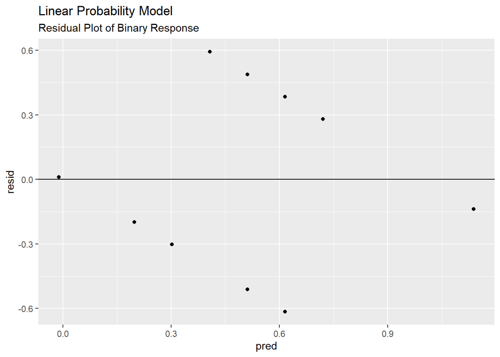

# Decomposition of Generalized Linear Model

A generalized linear model requires 3 main components:

1. Random Component- The distribution of the output. In this section the output of all the models is binary. For basic linear regression the output is normal.
2. Systematic Term- The linear combination of $\beta_{0}+\beta_{1}x_{1}+...+\beta_{p}x_{p}$.
3. Link Function- specifies the link between the random component and the systematic component. (Penn State)

# Logistic Regression Model

Logistic Regression is designed specifically to handle a binary response. This means it won’t struggle from the same pitfalls as linear regression. With logistic regression the predicted probabilities will all fall on a scale from 0-1, and statistical tests can be performed on both the predictions and the parameters.

The way logistic regression estimates its parameters is through the minimization of the negative log likelihood:

L($\beta$)=$\sum_{i=1}^{n} [-y_{i}(ln\ \pi(z))-(1-y_{i})ln(1-\pi(z))]$

or equivalently the maximization of the log likelihood:

L($\beta$)=$\sum_{i=1}^{n} [y_{i}(ln\ \pi(z))+(1-y_{i})ln(1-\pi(z))]$

$\pi(z)$- Function applied to z term, in the case of logistic regression it is known as the logit/sigmoid/logistic function.

logit = $\pi(z)=\frac{1}{1+e^{-z}}=\frac{e^{z}}{1+e^{z}}$

z-$\beta_{0} + \beta_{1}x_{1} + ... +\beta_{p}x_{p}$

By applying the logit function the prediction made is a probability just like with the linear probability model. However, now the probability is restricted to be within the range 0 to 1.

The plot below shows the logit function. The y-axis represents the probability that y=1. As the value of z ( $\beta_{0}+\beta_{1}x_{1}+...+\beta_{p}x_{p}$) increases, the probability of predicting y=1 increases. As the value of z decreases, the probability of predicting y=1 decreases, which is another way of saying the probability of predicting 0 increases.

The point at which the probability of predicting 1 and 0 is equal occurs when the value of z is 0. This means whenever the z value is above 0 the predicted value will be 1. Whenever the z value is below 0 the predicted value will be 0. (James et al.)

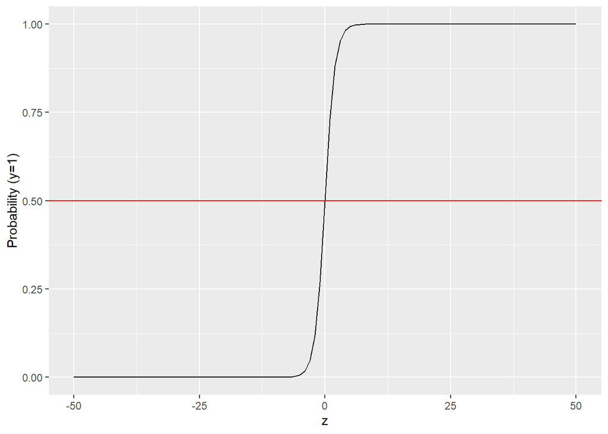

## Link Function ($\pi^{-1}(p)$)

In earlier sections we learned we could take the log of our dependent variable in order to address heteroscedasticity. After we performed the log transformation on the dependent variable we had to perform the exp on the results in order to convert our predictions back to their original units. The same concept applies with logistic regression.

Since the parameters are estimated using the sigmoid function, $\pi(z)=\frac{1}{1+e^{-z}}$, in order to interpret the parameter estimates in their original form we must take the inverse of the sigmoid function. This can be calculated as follows:

$\pi=\frac{e^{z}}{1+e^{z}}$

$e^{z}=\pi(1+e^{z})$

$e^{z}=\pi+\pi e^{z})$

$e^{z}-\pi e^{z}=\pi$

$e^{z}(1-\pi)=\pi$

$e^{z}=\frac{\pi}{1-\pi}$

$z=ln(\frac{\pi}{1-\pi})$

> z-$\beta_{0}+\beta_{1}x_{1}+...+\beta_{p}x_{p}$

> $\pi$ = Pr(y=1)

This $ln(\frac{\pi}{1-\pi})$ is known as the log-odds, and it is the link function used for the sigmoid function. The odds portion is just $\frac{\pi}{1-\pi}$.

If our parameter estimates took the form $5+.5x_{1}$ and $\beta_{1}$ is continuous, it can be interpreted as follows:

For a 1 unit increase in x1 the odds are multiplied by $e^{\beta_{1}}$ = 1.6487

For a 1 unit increase in x1 the odds of the outcome increase by $(e^{.5}-1)$% = 64.87%.

For confidence interval of $\beta_{1}$:

With 95% confidence for a 1 unit increase in x1 the outcome goes up by between ($e^{.5-(1.96)(se_{b_{1}})}-1$)%,($e^{.5+(1.96)(se_{b_{1}})}-1$)%

# Probit Regression

Probit regression has the same principle as logistic regression, which is applying a formula to restrict the probability between 0 and 1. Instead of using the sigmoid function, it applies the probit function:

$\pi(z)=\Phi(z)$

The parameter estimates are found by maximizing the log-likelihood just like with logistic regression, however instead of the logit function the probit function will we used:

L($\beta$)=$\sum_{i=1}^{n} [y_{i}(ln\ \pi(z))+(1-y_{i})ln(1-\pi(z))]$

$\pi(z)$=probit function, $\Phi(z)$

If the value of z is above 0 the probability will be above .5, meaning the prediction will be 1. If the value of z is less than 0 the probability will be below .5, meaning it will predict a value of 0.

These probabilities are calculated by using a t-table where the value entered, z, is the value found from the linear formula $\beta_{0}+\beta_{1}x_{1}+...+\beta_{p}x_{p}$.

The link function is just the inverse of the probit function on the probability,$\Phi^{-1}(\pi)$.

## Interpretation

The coefficients can be interpreted as the change in the z-score for a 1 unit change in the predictor.

# Why is Linear Probability Model A GLM

The linear probability model is GLM because it includes the same important aspects as the Logit and Probit models. It is used to model a binary response, meaning it is not continuous. Also, just like logistic and probit models it uses a link function. However, instead of some complicated function the link function is simply the identity function, or $\pi^{-1}(p)$ = z

#### Sources:

James, G., Witten, D., Hastie, T., & Tibshirani, R. (n.d.). An introduction to statistical learning: With applications in R.

Introduction to Glms: Stat 504. PennState: Statistics Online Courses. (n.d.). Retrieved November 19, 2022, from https://online.stat.psu.edu/stat504/lesson/6/6.1